# Introduction to the raustats package

David Mitchell

2019-12-22

# Introduction

The `raustats` package allows researchers to quickly search and download selected [Australian Bureau of Statistics (ABS)](http://www.abs.gov.au/) and [Reserve Bank of Australia (RBA)](http://www.rba.gov.au/) data in a programmatic and reproducible fashion. This facilitates seamless integration of ABS and/or RBA data into analysis projects, and enables automatic update to the latest available data.

## Australian Bureau of Statistics

The [Australian Bureau of Statistics (ABS)](http://www.abs.gov.au/) is Australia’s national statistical agency, providing trusted official statistics on a wide range of economic, social, population and environmental matters of importance to Australia. Key ABS statistical collections include:

- Australian National Accounts
- International Trade
- Consumer Price Index (CPI)
- Labour Force
- Population trends

## Reserve Bank of Australia

The [Reserve Bank of Australia (RBA)](http://www.rba.gov.au/) is Australia’s central bank. In addition to its legislative responsibilities, it collects and publishes statistics on money, credit, the Australian banking systems and other relevant economic metrics. Key RBA statistics include:

- Banking system assets and liabilities
- Money and credit statistics
- Household and business finances
- Interest rates
- Exchange rates
- Inflation and inflation expectations.

## ABS & RBA data availability

The ABS and RBA currently make most, or all, of their statistics primarily available through Excel- and/or CSV-format spreadsheets. The former typically require some additional re-formatting to produce well-formatted (tidy) data.

The functions in this package help facilitate access to ABS and RBA statistics through R, returning data in long-format (tidy-like) tables.

The ABS is also developing a data access API: [ABS.Stat](http://stat.data.abs.gov.au/), which is currently a Beta release and provides access to a subset of all ABS statistics. This package include functions to search and download data via the [ABS.Stat](http://stat.data.abs.gov.au/) API. Please note that as the API is still in development, changes in the API back-end may break the functions in this package.

## Main features of the `raustats` package:

- Access to all time series and cross-section statistics in the ABS statistical catalogue and on the RBA website
- Access to statistics available through the ABS Beta API: [ABS.Stat](http://stat.data.abs.gov.au)
- Ability to return `POSIXct` dates for easy integration into plotting and time-series analysis techniques
- Returns data in long (or tidy) format for direct integration with packages like `ggplot2`, `tidyr` and `dplyr`
- Support for regular expression (`grep`) style searching for data descriptions and names.

# Quick-start guide

This section provides a quick-start guide on how to download ABS and RBA statistics.

First, load the library:

```r
library(raustats)
```

## Downloading ABS Catalogue Statistics

The `abs_cat_stats` function downloads ABS statistics by ABS Catalogue number. For example, the latest Consumer Price Index (CPI) data set (ABS Catalogue no. 6401.0) can be downloaded with the following call:

```r
cpi_all <- abs_cat_stats("6401.0")
```

To download the latest CPI data reported in Table 1 only (ABS groups Tables 1 and 2 together), simply supply a regular expression to the `tables` argument:

```r
cpi <- abs_cat_stats("6401.0", tables="Table.+1\\D")
```

Alternatively, `tables` also accepts a regular expression that matches the table name as specified on the ABS data access page, as follows:

```r
cpi <- abs_cat_stats("6401.0", tables="CPI: All Groups, Index Numbers and Percentage Change")
```

Statistics from previous releases can be accessed using the `releases` argument. A more detailed explanation of the `abs_cat_stats` function and further examples are provided below.

## Downloading ABS data via [ABS.Stat](http://stat.data.abs.gov.au/)

The `abs_stats` function is used to download ABS statistics via the [ABS.Stat](http://stat.data.abs.gov.au/) API. For example, to download the latest CPI data series for ‘All Groups’ changes in prices across Australia and each of the eight capital cities, simply call:

```r
cpi_api <- abs_stats("CPI", filter=list(MEASURE=1, REGION=c(1:8,50),
                                        INDEX=10001, TSEST=10, FREQUENCY="Q"))
```

The package includes additional functions to search for datasets and data series available on [ABS.Stat](http://stat.data.abs.gov.au/). These are documented further below.

## Downloading RBA data

The `rba_stats` function downloads statistics available on the RBA website. For example, the latest statistics covering the RBA’s assets and liabilities (RBA Statistical Table A1) can be downloaded with the following call:

```r
rba_bs <- rba_stats("A1")
```

A more detailed explanation of `rba_stats` and other RBA data access functions is provided below.

# ABS statistics access functions

## ABS Catalogue statistics functions

The ABS Catalogue statistics functions are split into core functions:

- `abs_cat_stats`
- `abs_cat_tables`

and several helper functions:

The helper functions are called by the core functions and should generally not need to be called directly by users—though there are some cases where these functions may be useful.

### Finding available ABS Catalogue statistics

The ABS does not provide a consolidated searchable list of all current statistical collections available through the ABS Catalogue. A text search facility is available on the ABS website: www.abs.gov.au, but this package does not currently provide any functionality to access this facility. Instead, the `abs_cat_cachelist` data set contained in this package lists the more common ABS Catalogue statistics.

### Accessing ABS Catalogue statistics with `abs_cat_stats`

As shown in the Quick Start section, the `abs_cat_stats` function provides easy access to ABS statistics by ABS Catalogue Number. The following examples demonstrate typical uses of the function and the various function arguments.

The simplest use of the `abs_cat_stats` function is to download all tables available in a specified ABS Catalogue series. The Quick Start illustrated how to download all CPI tables. The following example downloads the latest quarterly national accounts statistics (ABS Catalogue no. 5206.0):

```r
ana_q <- abs_cat_stats(cat_no = "5206.0")
```

The function returns a long-format (tidy) table with the following columns:

- *series_id* – ABS series identifier
- *date* – Date-format date
- *value* – observation value
- *data_item_description* – data item name and description
- *series_type* – series type, generally one of: Original, Trend, Seasonally Adjusted
- *series_start* – series start date
- *series_end* – series end data
- *no_obs* – number of series observations
- *unit* – unit type (e.g. Percent, $ Millions, Index Numbers, Proportion)
- *data_type* – data type (e.g. Derived)
- *freq* (frequency) – Frequency (e.g. Annual, Quarterly, Monthly)
- *collection_month* – collection month (integer)
- *catalogue_no* – catalogue number (e.g. 5206.0, 6401.0)
- *publication_title* – ABS publication title
- *table_no* – ABS publication table number (integer)
- *table_title* – ABS publication table title.

```
#>         date series_id value
#> 1 1959-12-01 A2298668K   1.1
#> 2 1960-03-01 A2298668K   1.3
#> 3 1960-06-01 A2298668K   1.3
#> 4 1960-09-01 A2298668K   0.9
#> 5 1960-12-01 A2298668K   0.2
#> 6 1961-03-01 A2298668K  -0.5
#>                                                  data_item_description
#> 1 Gross domestic product: Chain volume measures - Percentage changes ;
#> 2 Gross domestic product: Chain volume measures - Percentage changes ;
#> 3 Gross domestic product: Chain volume measures - Percentage changes ;
#> 4 Gross domestic product: Chain volume measures - Percentage changes ;
#> 5 Gross domestic product: Chain volume measures - Percentage changes ;
#> 6 Gross domestic product: Chain volume measures - Percentage changes ;
#>   series_type series_start series_end no_obs    unit data_type    freq
```

[output cut: 27 more lines]

The `tables` argument allows users to select the set of catalogue tables to be downloaded by specifying a regular expression to pattern match the ABS table names, as specified on the ABS web page for the specified Catalogue number—by default (`tables = "all"`) the function automatically downloads all available tables from the specified catalogue number. The following sample code downloads Tables 1 and 2 from Catalogue no. 5206.0.

```r
ana_q <- abs_cat_stats(cat_no = "5206.0", tables=c("^Table 1\\D", "^Table 2\\D"))
```

The `releases` argument enables users to download data from a specified release. By default, the function downloads the latest available data (i.e. `releases="Latest"`). The format is a date object or character string specifying the month and year of release. For example, the following sample code downloads Table 1 from the December 2017 release of the quarterly national accounts.

```r
ana_2017Q4 <- abs_cat_stats(cat_no="5206.0", tables="Table 1", releases="Dec 2017")
## or
ana_2017Q4 <- abs_cat_stats(cat_no="5206.0", tables="Table 1", releases=as.Date("2017-12-01"))
```

The `releases` argument accepts multiple elements, as per the following example, which downloads Table 1 from each of the December 2016 and 2017 quarter national accounts:

```r
ana_Q4 <- abs_cat_stats(cat_no="5206.0", tables="Table 1", releases=c("Dec 2017","Dec 2016"))
```

The `abs_cat_stats` function is designed to download both ABS time series spreadsheets (`types="tss"`) and cross-section spreadsheets (`types="css"`)—‘Data Cubes’ in ABS terminology. ABS time series spreadsheets generally have a standard format, with a single column for each series, several header rows containing series metadata and a single row with the unique series identifier. ABS cross-section spreadsheet formats vary, depending on the number of dimensions (categories) available in the data set. These tables typically have multiple uniquely-identifying header rows.

Presently, the `abs_cat_stats` only includes functionality to download and process time series spreadsheets—functionality to handle ABS Data Cubes (cross-section spreadsheets, `types="css"`) is planned to be added in future versions.

In the meantime, it is possible to download data cubes using a sequence of `abs_cat_tables`–`abs_cat_download`–`abs_cat_unzip` and piping the result into a `read_excel` function call. The following example downloads ABS labour force table: *LM1 - Labour force status by Age, Greater Capital City and Rest of State (ASGS), Marital status and Sex*:

```r
lf_age <- abs_cat_tables("6291.0.55.001", include_urls=TRUE) %>%
  filter(grepl("LM1.+", item_name)) %>%
  .$path_zip %>%
  abs_cat_download %>%
  abs_cat_unzip %>%
  read_excel(sheet="Data 1", skip=3)
```

### Finding available ABS Catalogue tables with `abs_cat_tables`

The `abs_cat_tables` function returns a list of all tables for one or more specified ABS Catalogue numbers. It can be used to identify the relevant table(s) to download. The following two examples return all available tables for the latest quarterly national accounts (5206.0) and CPI (6401.0), respectively.

```r
ana_tables <- abs_cat_tables(cat_no="5206.0")
```

```
#>   cat_no release
#> 1 5206.0  Latest
#> 2 5206.0  Latest
#> 3 5206.0  Latest
#> 4 5206.0  Latest
#> 5 5206.0  Latest
#> 6 5206.0  Latest
#>                                                                        item_name
#> 1                                      Table 1. Key National Accounts Aggregates
#> 2    Table 2. Expenditure on Gross Domestic Product (GDP), Chain volume measures
#> 3           Table 3. Expenditure on Gross Domestic Product (GDP), Current prices
#> 4      Table 4. Expenditure on Gross Domestic Product (GDP), Chain price indexes
#> 5 Table 5. Expenditure on Gross Domestic Product (GDP), Implicit price deflators
#> 6                  Table 6. Gross Value Added by Industry, Chain volume measures
```

```r
## CPI
cpi_tables <- abs_cat_tables(cat_no="6401.0")
```

```
#>   cat_no release
#> 1 6401.0  Latest
#> 2 6401.0  Latest
#> 3 6401.0  Latest
#> 4 6401.0  Latest
#> 5 6401.0  Latest
#> 6 6401.0  Latest
#>                                                                                                            item_name
#> 1                                              TABLES 1 and 2. CPI: All Groups, Index Numbers and Percentage Changes
#> 2        TABLES 3 and 4. CPI: Groups, Weighted Average of Eight Capital Cities, Index Numbers and Percentage Changes
#> 3                                                                TABLE 5. CPI: Groups, Index Numbers by Capital City
#> 4 TABLE 6. CPI: Group, Sub-group and Expenditure Class Contribution to Change in All Groups Indexes, by Capital City
#> 5                     TABLE 7. CPI: Group, Sub-group and Expenditure Class, Weighted Average of Eight Capital Cities
#> 6                                          TABLE 8. CPI: Analytical Series, Weighted Average of Eight Capital Cities
```

The `abs_cat_tables` also has three additional arguments: `releases`, `types` and `include_urls`. The `releases` argument returns the list of downloadable tables from the specified release—by default `releases="Latest"`. Lists of available tables from earlier releases can be obtained by specifying the month and year of release, e.g.`releases = "Jun 2017"`. The `types` argument enables users to specify which file types to include. Options are ‘tss’ – ABS Time Series Spreadsheets, ‘css’ – ABS Data Cubes, and ‘pub’ – ABS Publications. The default is `types = c('tss', 'css')`. The `include_urls` argument specifies whether or not to include the URLs of available data tables in the returned results. The default is `include_urls=FALSE`.

The following example, returns all quarterly national accounts tables in the September and December 2017 quarter releases, and includes the table URLs.

```r
ana_tables <- abs_cat_tables(cat_no="5206.0", releases=c("Sep 2017", "Dec 2017"),
                             include_urls=TRUE)
```

```
#>   cat_no  release
#> 1 5206.0 Sep 2017
#> 2 5206.0 Sep 2017
#> 3 5206.0 Sep 2017
#> 4 5206.0 Sep 2017
#> 5 5206.0 Sep 2017
#> 6 5206.0 Sep 2017
#>                                                                        item_name
#> 1                                      Table 1. Key National Accounts Aggregates
#> 2    Table 2. Expenditure on Gross Domestic Product (GDP), Chain volume measures
#> 3           Table 3. Expenditure on Gross Domestic Product (GDP), Current prices
#> 4      Table 4. Expenditure on Gross Domestic Product (GDP), Chain price indexes
#> 5 Table 5. Expenditure on Gross Domestic Product (GDP), Implicit price deflators
#> 6                  Table 6. Gross Value Added by Industry, Chain volume measures
#>                                                                                                                                                                                                        path_xls
```

[output cut: 34 more lines]

And the following example illustrates use of the `abs_cat_tables` to return all available downloadable Data Cubes for a non-time series collection—the Australian Statistical Geography Standard (ASGS) main structure classification and digital boundaries (Catalogue no. 1270.0.55.001).

```r
asgs_files <- abs_cat_tables(cat_no="1270.0.55.001", types="css", include_urls=TRUE)
```

```
#>          cat_no release
#> 1 1270.0.55.001  Latest
#> 2 1270.0.55.001  Latest
#> 3 1270.0.55.001  Latest
#> 4 1270.0.55.001  Latest
#> 5 1270.0.55.001  Latest
#> 6 1270.0.55.001  Latest
#>                                                        item_name
#> 1   New South Wales Mesh Blocks ASGS Edition 2016 in .csv Format
#> 2          Victoria Mesh Blocks ASGS Edition 2016 in .csv Format
#> 3        Queensland Mesh Blocks ASGS Edition 2016 in .csv Format
#> 4   South Australia Mesh Blocks ASGS Edition 2016 in .csv Format
#> 5 Western Australia Mesh Blocks ASGS Edition 2016 in .csv Format
#> 6          Tasmania Mesh Blocks ASGS Edition 2016 in .csv Format
#>                                                                                                                                                                                  path_zip
#> 1 https://www.abs.gov.au/AUSSTATS/subscriber.nsf/log?openagent&1270055001_mb_2016_nsw_csv.zip&1270.0.55.001&Data%20Cubes&1FC672E70A77D52FCA257FED0013A0F7&0&July%202016&12.07.2016&Latest
#> 2 https://www.abs.gov.au/AUSSTATS/subscriber.nsf/log?openagent&1270055001_mb_2016_vic_csv.zip&1270.0.55.001&Data%20Cubes&F1EA82ECA7A762BCCA257FED0013A253&0&July%202016&12.07.2016&Latest
#> 3 https://www.abs.gov.au/AUSSTATS/subscriber.nsf/log?openagent&1270055001_mb_2016_qld_csv.zip&1270.0.55.001&Data%20Cubes&A6A81C7C2CE74FAACA257FED0013A344&0&July%202016&12.07.2016&Latest
#> 4  https://www.abs.gov.au/AUSSTATS/subscriber.nsf/log?openagent&1270055001_mb_2016_sa_csv.zip&1270.0.55.001&Data%20Cubes&5763C01CA9A3E566CA257FED0013A38D&0&July%202016&12.07.2016&Latest
#> 5  https://www.abs.gov.au/AUSSTATS/subscriber.nsf/log?openagent&1270055001_mb_2016_wa_csv.zip&1270.0.55.001&Data%20Cubes&6C293909851DCBFFCA257FED0013A3BF&0&July%202016&12.07.2016&Latest
#> 6 https://www.abs.gov.au/AUSSTATS/subscriber.nsf/log?openagent&1270055001_mb_2016_tas_csv.zip&1270.0.55.001&Data%20Cubes&A9B01B4DACD0BFEFCA257FED0013A3FC&0&July%202016&12.07.2016&Latest
```

### Listing all available Catalogue releases with `abs_cat_releases`

The `abs_cat_releases` function returns a table of all available past releases for a specified ABS Catalogue number. If `include_urls=TRUE` (default is `FALSE`), the function includes the full URL for each of the available releases. The default is `include_urls=FALSE`. The following examples return all available releases for the quarterly national accounts (5206.0) and CPI (6401.0), respectively.

```r
ana_releases <- abs_cat_releases(cat_no="5206.0")
```

```
#>                                                                          releases
#> 1 Australian National Accounts: National Income, Expenditure and Product Jun 2019
#> 2 Australian National Accounts: National Income, Expenditure and Product Mar 2019
#> 3 Australian National Accounts: National Income, Expenditure and Product Dec 2018
#> 4 Australian National Accounts: National Income, Expenditure and Product Sep 2018
#> 5 Australian National Accounts: National Income, Expenditure and Product Jun 2018
#> 6 Australian National Accounts: National Income, Expenditure and Product Mar 2018
```

```r
## CPI
cpi_releases <- abs_cat_releases(cat_no="6401.0", include_urls=TRUE)
```

```
#>                                   releases
#> 1 Consumer Price Index, Australia Jun 2019
#> 2 Consumer Price Index, Australia Mar 2019
#> 3 Consumer Price Index, Australia Dec 2018
#> 4 Consumer Price Index, Australia Sep 2018
#> 5 Consumer Price Index, Australia Jun 2018
#> 6 Consumer Price Index, Australia Mar 2018
#>                                                                                                            urls
#> 1 https://www.abs.gov.au/ausstats/abs@.nsf/allprimarymainfeatures/03A4A18ECF3CDA26CA2584A20012C958?opendocument
#> 2 https://www.abs.gov.au/ausstats/abs@.nsf/allprimarymainfeatures/6061564BA67694A3CA2584470020ECC2?opendocument
#> 3 https://www.abs.gov.au/ausstats/abs@.nsf/allprimarymainfeatures/97DE913203378356CA2583E5001D660C?opendocument
#> 4 https://www.abs.gov.au/ausstats/abs@.nsf/allprimarymainfeatures/A10C0C137242732CCA258391001B1285?opendocument
#> 5 https://www.abs.gov.au/ausstats/abs@.nsf/allprimarymainfeatures/7925354FEECF816FCA258336001791A9?opendocument
#> 6 https://www.abs.gov.au/ausstats/abs@.nsf/allprimarymainfeatures/E64200D366CAEB72CA2582D400151A64?opendocument
```

### Other ABS Catalogue helper functions

As already noted, there are several ABS Catalogue helper functions that are called by `abs_cat_stats` and `abs_cat_tables`—that download and parse the ABS Catalogue table files. The main ones are:

- `abs_cat_download`
- `abs_cat_unzip`
- `abs_read_tss`

The following examples illustrate the use of these functions.

The `abs_cat_download` function downloads and saves ABS Catalogue tables from a supplied URL. It is called inside the `abs_cat_stats` and can be used directly to download one or more ABS Catalogue table files. It is most usefully used in conjunction with the `abs_cat_tables` function, as follows:

```r
tables <- abs_cat_tables("5206.0", releases="Latest", include_urls=TRUE)
downloaded_tables <- abs_cat_download(tables$path_xls, exdir=tempdir())
print(downloaded_tables)
```

The `abs_cat_unzip` function extracts Excel files from compressed ABS zip archives (see example below). It uses the `utils::unzip` function (using some standard file locations). There are two arguments: `files` and `exdir` which have a similar meaning to the `utils::unzip` equivalent arguments. By default `exdir = tempdir()`.

```r
extracted_files <- abs_cat_unzip(downloaded_tables)
print(extracted_files)
```

```
#> named list()
```

The `abs_read_tss` function extracts data from standard-formatted ABS Catalogue time series spreadsheets and returns it as a long-format (tidy) data frame. The next example shows use of the function to read Table 1 from the national accounts (Catalogue 5206.0).

```r
ana_q <- abs_read_tss(extracted_files)
```

## ABS.Stat statistics access functions

The `raustats` package also includes a range of functions to list, search and download data sets and statistics available through [ABS.Stat](http://stat.data.abs.gov.au/) API. The following subsections outline the key functions.

### Finding available data with `abs_datasets`

```r
datasets <- abs_datasets()
head(datasets)
```

[output not shown]

#### Cached list of available ABS.Stat datasets `abs_cachelist`

For performance, a cached list of datasets available through the [ABS.Stat](http://stat.data.abs.gov.au/) API is provided in the `abs_cachelist` data set included with `raustats`. `abs_cachelist` is the default source used in `abs_search()` and `abs_stats()` to find matching ABS datasets.

By default, `abs_cachelist` is in English. To search indicators in a different language, you can download an updated copy of `abs_cachelist` using `abs_datasets()` ans specifying a different language.

### Checking dataset dimensions with `abs_dimensions()`

The `abs_dimensions()` functions lists the name of all available dimensions and the respective dimension type. Typical dimension types are: ‘Dimension’, ‘TimeDimension’ and ‘Attribute’. ‘Dimension’ attributes are used in the `filter` argument of `abs_stats` function. The following example lists the data dimensions of the ‘CPI’ dataset.

```r
abs_dimensions('CPI')
```

```
#>          name          type
#> 1     MEASURE     Dimension
#> 2      REGION     Dimension
#> 3       INDEX     Dimension
#> 4       TSEST     Dimension
#> 5   FREQUENCY     Dimension
#> 6        TIME TimeDimension
#> 7  OBS_STATUS     Attribute
#> 8 TIME_FORMAT     Attribute
```

A list of all available dimension codes and descriptions for a particular dataset can be viewed by selecting the relevant dataset from `abs_cachelist` or an updated cache list returned by `abs_cache`.

```r
str(abs_cachelist[["CPI"]])
```

### Search available data with `abs_search()`

The `abs_search` function essentially has two modes of operation:

1. ‘dataset search’ mode, and
2. ‘indicator search’ mode.

In dataset search mode, the function searches and returns datasets matching the specified regular expression. The following examples demonstrate use of the function to find ABS datasets relating to the CPI and labour force. The `code_only` argument specifies whether the function returns all information or just the matching dataset identifiers.

```r
abs_search("CPI|consumer price index")
```

```
#>    id agencyID                                   name
#> 1 CPI      ABS Consumer Price Index (CPI) 17th Series
```

```r
abs_search("CPI|consumer price index", code_only=TRUE)
```

```
#> [1] "CPI"
```

```r
abs_search("labour force")
```

```
#>                           id agencyID
#> 1          ABS_ACLD_LFSTATUS      ABS
#> 2         ABS_CENSUS2011_B37      ABS
#> 3     ABS_CENSUS2011_B37_LGA      ABS
#> 4  ABS_CENSUS2011_B37_SA1_SA      ABS
#> 5         ABS_CENSUS2011_B42      ABS
#> 6     ABS_CENSUS2011_B42_LGA      ABS
#> 7  ABS_CENSUS2011_B42_SA1_SA      ABS
#> 8            ABS_C16_G43_LGA      ABS
#> 9             ABS_C16_G43_SA      ABS
#> 10           ABS_C16_G44_LGA      ABS
#> 11            ABS_C16_G44_SA      ABS
#> 12           ABS_C16_G45_LGA      ABS
#> 13            ABS_C16_G45_SA      ABS
#> 14           ABS_C16_G56_LGA      ABS
```

[output cut: 39 more lines]

```r
abs_search("^labour force$")
```

```
#>   id agencyID         name
#> 1 LF      ABS Labour Force
```

In indicator search mode, the function searches through all dimensions of a specific dataset and returns a list of dimensions and dimension contents matching all the provided regular expressions. The following examples demonstrates use of the function to find indicators within the CPI data set.

```r
abs_search(c("All groups CPI","Sydney"), dataset="CPI")
```

```
#> $REGION
#>   Code Description
#> 1    1      Sydney
#>
#> $INDEX
#>       Code
#> 1    10001
#> 133 115902
#> 134 115901
#> 135 115922
#> 136 115941
#> 137 115961
#> 138 117101
#> 139 117104
#> 140 117107
```

[output cut: 32 more lines]

```r
abs_search(c("All groups CPI","Sydney"), dataset="CPI", code_only=TRUE)
```

```
#> $REGION
#> [1] "1"
#>
#> $INDEX
#>  [1] "10001"  "115902" "115901" "115922" "115941" "115961" "117101" "117104"
#>  [9] "117107" "117121" "117124" "117127" "128058" "128061" "117144" "104122"
#> [17] "131197" "131199" "131198" "999901"
```

### Downloading data with `abs_stats()`

The `abs_stats()` function returns data from specified datasets available via the [ABS.Stat](http://stat.data.abs.gov.au/) API. The following section outlines typical use of the `abs_stats()` function, and also describes each of the core function arguments.

The following example downloads original All groups CPI index numbers for each of the eight Australian state and territory capital cities and also the average for all capital cities.

```r
cpi <- abs_stats(dataset="CPI", filter=list(MEASURE=1, REGION=c(1:8,50),
                                            INDEX=10001, TSEST=10, FREQUENCY="Q"))
```

The filter conditions are:

- `MEASURE=1` – ‘Index Numbers’
- `REGION=c(1:8,50)` – Each of the eight capital cities (1–8) and all eight capital cities (50)
- `INDEX=10001` – ‘All groups CPI’
- `TSEST=10` – ‘Original’ observations
- `FREQUENCY=Q` – Quarterly observations

```
#>         measure region          index adjustment_type frequency     time values
#> 1 Index Numbers Sydney All groups CPI        Original Quarterly Sep-1948    3.7
#> 2 Index Numbers Sydney All groups CPI        Original Quarterly Dec-1948    3.7
#> 3 Index Numbers Sydney All groups CPI        Original Quarterly Mar-1949    3.9
#> 4 Index Numbers Sydney All groups CPI        Original Quarterly Jun-1949    3.9
#> 5 Index Numbers Sydney All groups CPI        Original Quarterly Sep-1949    4.0
#> 6 Index Numbers Sydney All groups CPI        Original Quarterly Dec-1949    4.1
#>   obs_status unknown agency_id                     agency_name
#> 1          0      NA       ABS Australian Bureau of Statistics
#> 2          0      NA       ABS Australian Bureau of Statistics
#> 3          0      NA       ABS Australian Bureau of Statistics
#> 4          0      NA       ABS Australian Bureau of Statistics
#> 5          0      NA       ABS Australian Bureau of Statistics
#> 6          0      NA       ABS Australian Bureau of Statistics
#>                             dataset_name
#> 1 Consumer Price Index (CPI) 17th Series
#> 2 Consumer Price Index (CPI) 17th Series
#> 3 Consumer Price Index (CPI) 17th Series
#> 4 Consumer Price Index (CPI) 17th Series
#> 5 Consumer Price Index (CPI) 17th Series
#> 6 Consumer Price Index (CPI) 17th Series
```

The `filter` argument can also be set equal to “all”, in which case the function will attempt to download all observations available for the specified dataset.

#### ABS.Stat query download constraints

If the data request is large it may breach the [ABS.Stat](http://stat.data.abs.gov.au/) API query length, record and/or session time constraints. [ABS.Stat](http://stat.data.abs.gov.au/) has a query string length limit (maximum of 1000 characters) on URL queries, a record return limit (1 million records) and session time limits (maximum 10-minute session time limit).[^1] Queries that breach these limits will need to be re-specified as multiple separate calls to obtain the required data.

For example, the following `abs_stats` function call, attempts to download all series available for the CPI dataset, but the specified query length (1191 characters) exceeds maximum request URL character limit.

```r
cpi <- abs_stats(dataset="CPI", filter="all")
```

By default, `abs_stats` checks whether the query string length and the estimated number of records to be returned and will halt execution if the query breaches any of these conditions. Setting the `enforce_api_limits = FALSE` (default: `TRUE`) will ignore these checks and submit the query to the [ABS.Stat](http://stat.data.abs.gov.au/) API anyway—though this is not recommended.

```r
cpi <- abs_stats(dataset="CPI", filter="all", enforce_api_limits=FALSE)
```

Setting the `return_url = TRUE` (default: `FALSE`) will return the RESTful URL query string, but does not submit the query to the [ABS.Stat](http://stat.data.abs.gov.au/) API, see the following example function call and output.

```r
abs_stats(dataset="CPI", filter=list(MEASURE=1, REGION=c(1:8,50),
                                     INDEX=10001, TSEST=10, FREQUENCY="Q"),
          return_url=TRUE)
```

```
#> [1] "http://stat.data.abs.gov.au/SDMX-JSON/data/CPI/1.1+2+3+4+5+6+7+8+50.10001.10.Q/all?detail=Full&dimensionAtObservation=AllDimensions"
```

The `abs_search` function can be used to specify the filter. For example, the following code block produces the same filter list, specified in the previous example, and can subsequently be supplied to the `abs_stats` `filter` argument.

```r
filter_lst <- abs_search(c("Index numbers", "All groups",
                           "Sydney|Melbourne|Brisbane|Adelaide|Perth|Hobart|Darwin|Canberra|capital cities",
                           "Original", "Quarterly"),
                         dataset="CPI", code_only=TRUE)
cpi <- abs_stats("CPI", filter = filter_lst)
```

#### Splitting an ABS filter list into multiple short queries

The `purrr` package functions: `map` and `cross` can be used to split a long query into a list of several shorter length queries to submit to [ABS.Stat](http://stat.data.abs.gov.au/). For example, the following code block first uses `abs_search` to create a filter list to download estimated resident population (ERP), by state/territory, age (year) and sex, for June 2017, and splits the filter into groups no longer than 26 elements in length (`purrr::map` and `split`), and combines them into complete list (`purrr::cross`). The final step imports the data by iterating over the filter list (`ds_filter`) using `lapply` and combining the results into a data frame using `bind_rows`.

```r
## ERP dataset ID
abs_ds <- abs_search(pattern="quarterly.*population.*estimates") %>%
  select(id) %>% unlist;

## Create filter
ds_filter <- abs_search(pattern=c("Estimated Resident Population", "Males|Females|Persons",
                                  "^\\d{1,3}$", "Jun-2017"),
                        dataset=abs_ds, code_only=TRUE) %>%
  map(~ .x %>% split(., ceiling(seq_along(.)/26))) %>%
  cross;

## Download Jun 2017 ERP
erp_st_age_sex_2017 <-
  lapply(ds_filter,
         function(i_filter)
           abs_stats(abs_ds,
                     start_date="2017-Q2", end_date="2017-Q2",
                     filter=i_filter)
         ) %>%
  bind_rows;
```

#### Other ABS.Stat query arguments

Users can also limit the date range to return by specifying one or both`start_date` and `end_date` arguments. These accept either a numeric or character arguments—if numeric it must be a four-digit year. If a character string it can be either a monthly, quarterly, half-year or financial year as formatted as follows: month – ‘2016-M01’, quarter – ‘2016-Q1’, half-year – ‘2016-B2’, financial year – ‘2016-17’. The following example returns all CPI observations between September 2015 and June 2018.

```r
cpi <- abs_stats(dataset="CPI", filter=filter_lst,
                 start_date = "2015-Q3", end_date = "2018-Q2")
```

The other arguments `dimensionAtObservation` and `detail` provide refinements to the URL query. These need not be modified by the user—the defaults are: `dimensionAtObservation='AllDimensions` and `detail='Full'`.

# RBA statistics access functions

### Finding available RBA data tables with `rba_table_cache`

The `rba_table_cache` function returns a dataset of all available RBA statistical tables. The function scans the RBA website and returns a list of all [Statistical tables](https://www.rba.gov.au/statistics/tables/), [Historical data tables](https://www.rba.gov.au/statistics/historical-data.html) and [Discontinued data tables](https://www.rba.gov.au/statistics/discontinued-data.html). (The `rba_cachelist` data set included in this package contains a pre-saved list of all available RBA statistical tables.)

The dataset has four columns:

- table_code
- table_name
- table_type – one of either statistical table, historical data or discontinued data.
- url.

The `rba_table_cache` function has no arguments. The following example shows use of the function and the returned output.

```r
rba_cache <- rba_table_cache()
```

```
#>   table_no
#> 1       A1
#> 2       A1
#> 3       A2
#> 4       A3
#> 5       A4
#> 6       A5
#>                                                              table_name
#> 1                                      Liabilities and Assets - Summary
#> 2                                     Liabilities and Assets - Detailed
#> 3                                               Monetary Policy Changes
#> 4                                      Open Market Operations - Current
#> 5 Foreign Exchange Transactions and Holdings of Official Reserve Assets
#> 6               Daily Foreign Exchange Market Intervention Transactions
#>           table_type
#> 1 statistical tables
#> 2 statistical tables
#> 3 statistical tables
#> 4 statistical tables
#> 5 statistical tables
#> 6 statistical tables
#>                                                                  url
#> 1  https://www.rba.gov.au/statistics/tables/xls/a01whist-summary.xls
#> 2 https://www.rba.gov.au/statistics/tables/xls/a01whist-detailed.xls
#> 3           https://www.rba.gov.au/statistics/tables/xls/a02hist.xls
#> 4               https://www.rba.gov.au/statistics/tables/xls/a03.xls
#> 5           https://www.rba.gov.au/statistics/tables/xls/a04hist.xls
#> 6           https://www.rba.gov.au/statistics/tables/xls/a05hist.xls
```

### Search available data with `rba_search()`

The `rba_search` function scans the RBA table cache for statistical tables matching a regular expression supplied to `pattern`. The `fields` argument specifies the fields in the RBA table cache to search—by default the function searches the `table_code` and `table_name` fields only. The `ignore.case` argument allows for case sensitive regular expression matching—the default is case insensitive matching (`ignore.case=TRUE`). The `update_cache` argument specifies whether the function uses the list of RBA tables supplied with the package `rba_cachelist` (`update_cache=FALSE`, the default) or to update list of tables from the RBA website (`update_cache=TRUE`).

```r
rba_search(pattern = "Liabilities and Assets")
```

```
#>   table_no                        table_name         table_type
#> 1       A1  Liabilities and Assets - Summary statistical tables
#> 2       A1 Liabilities and Assets - Detailed statistical tables
#>                                                                  url
#> 1  https://www.rba.gov.au/statistics/tables/xls/a01whist-summary.xls
#> 2 https://www.rba.gov.au/statistics/tables/xls/a01whist-detailed.xls
```

### Accessing RBA statistical tables with `rba_stats()`

As previously outlined in the Quick Start section, the `rba_stats()` function provides easy access to RBA statistical tables. The `rba_stats()` function has three mutually-exclusive table selection arguments: `table_no`, `pattern`, and `url`, for selecting RBA statistical tables. Specifying `table_no` selects tables matching the specified RBA table number, e.g. A1, B1, B11.1. Specifying `pattern` selects all RBA tables matching the regular expression specified in `pattern`. The `url` argument can be used to specify one or more valid RBA statistical table URLs.

The function returns a long-format (tidy) table with the following columns:

- *series_id* – RBA series identifier
- *date* – Date-format date
- *value* – observation value
- *title* – data item name
- *description* – data item description
- *frequency* – Frequency (e.g. Annual, Quarterly, Monthly, Weekly, Daily)
- *type* – series type, one of Original, Trend, Seasonally Adjusted
- *units* – unit of measure (e.g. Percent, $ Millions, Index Numbers, Proportion)
- *source* – data source organisation
- *data_type* – data type (e.g. Original, Derived)
- *table_no* – RBA statistics table number (if available)
- *table_title* – RBA statistics table title.

The following examples demonstrate typical uses of the function and the various function arguments. The first example downloads RBA Statistical Table A1 – Liabilities and Assets using `table_no`.

```r
rba_a1 <- rba_stats(table_no = "A1")
```

```
#>         date series_id value                                 title
#> 1 1994-06-01 ARBALCRFW   633 Capital and Reserve Bank Reserve Fund
#> 2 1994-06-08 ARBALCRFW   633 Capital and Reserve Bank Reserve Fund
#> 3 1994-06-15 ARBALCRFW   633 Capital and Reserve Bank Reserve Fund
#> 4 1994-06-22 ARBALCRFW   633 Capital and Reserve Bank Reserve Fund
#> 5 1994-06-29 ARBALCRFW   633 Capital and Reserve Bank Reserve Fund
#> 6 1994-07-06 ARBALCRFW   633 Capital and Reserve Bank Reserve Fund
#>                                                             description
#> 1 Capital and Reserve Bank Reserve Fund; see Notes for further details.
#> 2 Capital and Reserve Bank Reserve Fund; see Notes for further details.
#> 3 Capital and Reserve Bank Reserve Fund; see Notes for further details.
#> 4 Capital and Reserve Bank Reserve Fund; see Notes for further details.
#> 5 Capital and Reserve Bank Reserve Fund; see Notes for further details.
#> 6 Capital and Reserve Bank Reserve Fund; see Notes for further details.
#>   frequency     type     units source publication_date table_no
#> 1    Weekly Original $ million    RBA       2019-12-20       A1
#> 2    Weekly Original $ million    RBA       2019-12-20       A1
#> 3    Weekly Original $ million    RBA       2019-12-20       A1
#> 4    Weekly Original $ million    RBA       2019-12-20       A1
#> 5    Weekly Original $ million    RBA       2019-12-20       A1
#> 6    Weekly Original $ million    RBA       2019-12-20       A1
#>                                                     table_name
#> 1 RESERVE BANK OF AUSTRALIA - LIABILITIES AND ASSETS - SUMMARY
#> 2 RESERVE BANK OF AUSTRALIA - LIABILITIES AND ASSETS - SUMMARY
#> 3 RESERVE BANK OF AUSTRALIA - LIABILITIES AND ASSETS - SUMMARY
#> 4 RESERVE BANK OF AUSTRALIA - LIABILITIES AND ASSETS - SUMMARY
#> 5 RESERVE BANK OF AUSTRALIA - LIABILITIES AND ASSETS - SUMMARY
#> 6 RESERVE BANK OF AUSTRALIA - LIABILITIES AND ASSETS - SUMMARY
```

```r
rba_a1 <- rba_stats(pattern = "Liabilities and Assets.+Summary")
```

```r
a1_tables <- rba_search(pattern = "Liabilities and Assets.+Summary")
rba_a1 <- rba_stats(url = a1_tables$url)
```

```
#>         date series_id value                                 title
#> 1 1994-06-01 ARBALCRFW   633 Capital and Reserve Bank Reserve Fund
#> 2 1994-06-08 ARBALCRFW   633 Capital and Reserve Bank Reserve Fund
#> 3 1994-06-15 ARBALCRFW   633 Capital and Reserve Bank Reserve Fund
#> 4 1994-06-22 ARBALCRFW   633 Capital and Reserve Bank Reserve Fund
#> 5 1994-06-29 ARBALCRFW   633 Capital and Reserve Bank Reserve Fund
#> 6 1994-07-06 ARBALCRFW   633 Capital and Reserve Bank Reserve Fund
#>                                                             description
#> 1 Capital and Reserve Bank Reserve Fund; see Notes for further details.
#> 2 Capital and Reserve Bank Reserve Fund; see Notes for further details.
#> 3 Capital and Reserve Bank Reserve Fund; see Notes for further details.
#> 4 Capital and Reserve Bank Reserve Fund; see Notes for further details.
#> 5 Capital and Reserve Bank Reserve Fund; see Notes for further details.
#> 6 Capital and Reserve Bank Reserve Fund; see Notes for further details.
#>   frequency     type     units source publication_date table_no
#> 1    Weekly Original $ million    RBA       2019-12-20       A1
#> 2    Weekly Original $ million    RBA       2019-12-20       A1
#> 3    Weekly Original $ million    RBA       2019-12-20       A1
#> 4    Weekly Original $ million    RBA       2019-12-20       A1
#> 5    Weekly Original $ million    RBA       2019-12-20       A1
#> 6    Weekly Original $ million    RBA       2019-12-20       A1
#>                                                     table_name
#> 1 RESERVE BANK OF AUSTRALIA - LIABILITIES AND ASSETS - SUMMARY
#> 2 RESERVE BANK OF AUSTRALIA - LIABILITIES AND ASSETS - SUMMARY
#> 3 RESERVE BANK OF AUSTRALIA - LIABILITIES AND ASSETS - SUMMARY
#> 4 RESERVE BANK OF AUSTRALIA - LIABILITIES AND ASSETS - SUMMARY
#> 5 RESERVE BANK OF AUSTRALIA - LIABILITIES AND ASSETS - SUMMARY
#> 6 RESERVE BANK OF AUSTRALIA - LIABILITIES AND ASSETS - SUMMARY
```

Again, the `update_cache` argument specifies whether the function uses the list of RBA tables supplied with the package with the package `rba_cachelist` (the default) or to update list of tables from the RBA website. The `rba_stats` function also optionally accepts `rba_search` arguments: `fields` and `ignore.case`, for informing pattern matching.

At present, the `rba_stats` function only handles [Statistical tables](https://www.rba.gov.au/statistics/tables/), which have a consistently structured format comprising full metadata and observations. Functionality to handle [Historical data tables](https://www.rba.gov.au/statistics/historical-data.html) and [Discontinued data tables](https://www.rba.gov.au/statistics/discontinued-data.html) are yet to be added.

### Other RBA helper functions

There are also two RBA helper functions that are called by `rba_stats`—that download and parse the RBA statistical tables. These additional functions should not ordinarily need to be called directly, but there may be situations in which users wish to access these functions directly. The functions are:

- `rba_file_download`
- `rba_read_tss`

The following examples illustrate the use of these functions.

The `rba_download` function downloads and saves RBA tables from a supplied URL, and returns a character vector of the saved local filenames. It is called inside the `rba_stats` function and can be used to directly download one or more RBA statistical table files. It is most usefully used in conjunction with the `rba_search` function.

```r
a1_tables <- rba_search(pattern = "Liabilities and Assets.+Summary")
downloaded_tables <- rba_file_download(a1_tables$url, exdir=tempdir())
print(downloaded_tables)
```

The `rba_read_tss` function extracts data from standard-format RBA statistical tables and returns it as a long-format (tidy) data frame. It is also called by the `rba_stats` function. The following call will extract data from the previously downloaded tables.

```r
a1_data <- rba_read_tss(downloaded_tables)
```

# Using data returned by `raustats`

```r
capex_q <-
  abs_cat_stats("5625.0",
                tables=c("Actual Expenditure by Type of Asset and Industry - Current Prices",
                         "Actual Expenditure, By Type of Industry - Chain Volume Measures",
                         "Actual and Expected Capital Expenditure by Industry.+:Current Prices"))
```

Then add a new variable denoting Australian state/territory.

```r
library(dplyr)
## Add state/territory variable
capex_q <- capex_q %>%
  mutate(state = sub(sprintf(".*(%s).*",
                             paste(c("New South Wales","Victoria","Queensland","South Australia",
                                     "Western Australia","Tasmania","Northern Territory",
                                     "Australian Capital Territory","Total \\(State\\)"),
                                   collapse="|")),
                     "\\1", data_item_description, ignore.case=TRUE))
```

Finally, plot quarterly time series mining sector capital expenditure (at current prices) by Australian state and territory using `ggplot`.

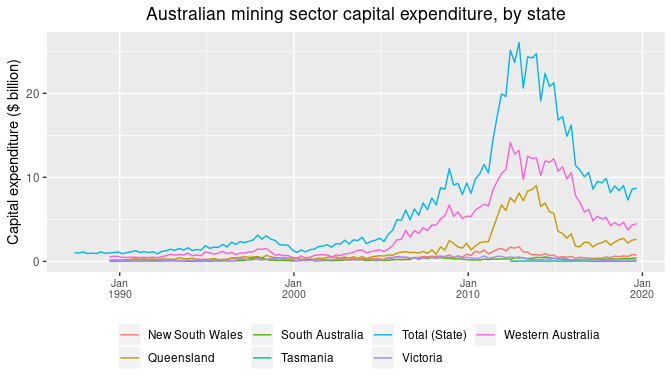

```r
library(ggplot2)
## Filter mining capital expenditure
capex_q_min <- capex_q %>%
  filter(grepl("mining", data_item_description, ignore.case=TRUE)) %>%
  filter(grepl("actual", data_item_description, ignore.case=TRUE)) %>%
  filter(grepl("current price", data_item_description, ignore.case=TRUE)) %>%
  filter(grepl("Total \\(Type of Asset.+\\)", data_item_description, ignore.case=TRUE))

ggplot(data=capex_q_min) +
  geom_line(aes(x=date, y=value/10^3, colour=state)) +
  scale_x_date(date_labels="%b\n%Y") +
  scale_y_continuous(limits=c(0, NA)) +
  labs(title="Australian mining sector capital expenditure, by state",
       y="Capital expenditure ($ billion)", x=NULL) +
  guides(colour = guide_legend(title=NULL)) +
  theme(plot.title = element_text(hjust=0.5),
        legend.box = "horizontal",
        legend.position = "bottom",
        axis.text.x=element_text(angle=0, size=8))
```

# Unresolved issues

There are a few behaviours of the [ABS.Stat](http://stat.data.abs.gov.au/) API that may help explain any unexpected results. As the [ABS.Stat](http://stat.data.abs.gov.au/) API is still in Beta release and subject to revision, some of these issues will be addressed in future versions of the `raustats` package, as [ABS.Stat](http://stat.data.abs.gov.au/) transitions towards a stable release version.

## Searching in other languages

The [ABS.Stat](http://stat.data.abs.gov.au/) API (Beta version) includes scope to cater to multiple languages. However, at the time of writing, French appears to be the only other language included in the data sets. Moreover, the text for many records that are denoted as French appear to be in English. The ABS API calling functions included in this library allow users to specify their preferred language, but this functionality has been little tested to date.

## Query, data and session constraints

As already noted, the [ABS.Stat](http://stat.data.abs.gov.au/) API has a query string length limit (1000 characters) and record return limit (1 million records). We have not tested how rigorously these limits are enforced. Accordingly, the `abs_stats` function includes the `enforce_api_limits` argument to catch these limits before the query is submitted. The argument also allows the user to override the limits and submit the query anyway. This argument may be deprecated in future versions.

The [ABS.Stat](http://stat.data.abs.gov.au/) API also has a 10-minute session time limit for users to download datasets via the SDMX service. The functions in `raustats` almost exclusively use the SDMX-JSON query interface, so it is not clear whether the session time limit applies. If time limits are an issue, the ABS advises users to submit multiple smaller requests to retrieve the required data.

# Resources

- [ABS.Stat – http://stat.data.abs.gov.au/](http://stat.data.abs.gov.au/)
- [ABS.Stat FAQ](http://stat.data.abs.gov.au/)
[^1]: See the [ABS.Stat Web Services User Guide FAQ](http://www.abs.gov.au/ausstats/abs@.nsf/Lookup/by%20Subject/1407.0.55.002~User%20Guide~Main%20Features~Frequently%20Asked%20Questions~9) for further details.